# Pakiet missMDA

March 31, 2020

## Pakiet missMDA

- umożliwia obsługę brakujących wartości w metodach czynnikowych  
  (PCA, CA, MCA, MFA, FAMD),
- imputuje brakujące wartości w taki sposób, że przypisane wartości nie mają wag.  
  (tj. nie mają wpływu na wyniki; metody są wykonywane tylko z zaobserwowanymi wartościami),
- oparty na metodach redukcji wymiarów , pakiet missMDA z powodzeniem radzi sobie z dużymi, złożonymi zbiorami danych,
- może być stosowany do imputacji zmiennych zarówno numerycznych jak i kategorycznych.

## Objaśnienia

- Analiza czynnikowa  
  Metoda statystyczna, której celem jest opisanie zależności między zaobserwowanymi, skorelowanymi zmiennymi przy pomocy możliwie mniejszej liczby zmiennych, które są wzajemnie nieskorelowane.
- Analiza głównych składowych  
  Zbiór danych składający się z N obserwacji, z których każda obejmuje K zmiennych, można interpretować jako chmurę N punktów w przestrzeni K-wymiarowej. Celem PCA jest taki obrót układu współrzędnych, aby maksymalizować w pierwszej kolejności wariancję pierwszej współrzędnej, następnie wariancję drugiej współrzędnej itd.. W ten sposób konstruowana jest nowa przestrzeń obserwacji, w której najwięcej zmienności wyjaśniają początkowe czynniki.

## Algorytm PCA

|  | Mouse1 | Mouse2 | Mouse3 | Mouse4 | Mouse5 |
| --- | --- | --- | --- | --- | --- |
| Gene1 | 10 | 11 | 3 | 2 | 2 |
| Gene2 | 6 | 4 | 3 | 2.8 | 3 |
| Gene3 | 12 | 9 | 2.5 | 1.3 | 2 |
| Gene4 | 5 | 7 | 2 | 4 | 7 |

## Algorytm PCA

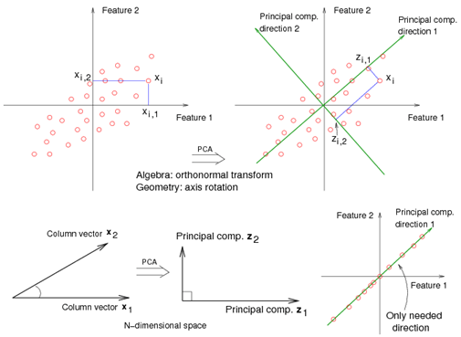

## Algorytm PCA

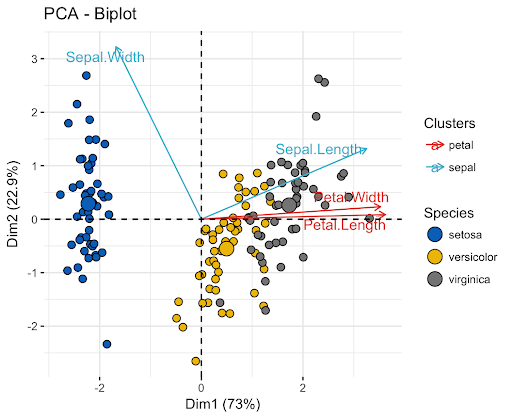

## Zbiór danych airquality

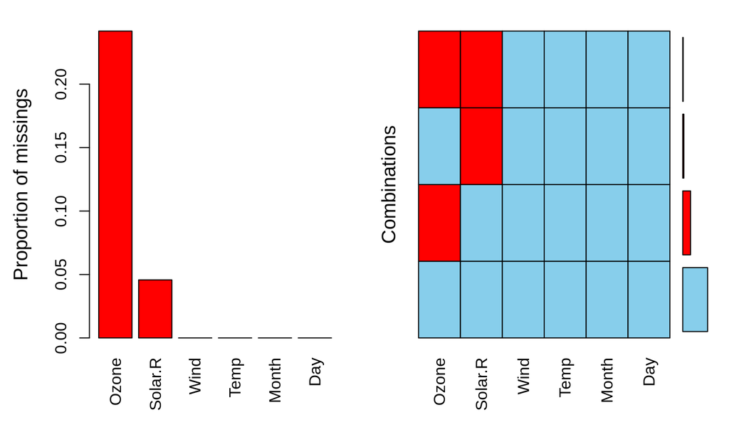

**1.** Dla kroswalidacji leave-one-out (loo) każda komórka ramki danych jest alternatywnie usuwana i prognozowana za pomocą modelu PCA. Zwracana jest liczba wymiarów, która prowadzi do najmniejszego średniego błędu prognozowania (MSEP).

```r
nb1 <- estim_ncpPCA(airquality, method='Regularized',
                    verbose=FALSE, method.cv="loo", ncp.min=1)
plot(1:5, nb1$criterion, xlab="nb dim", ylab="MSEP")
title(paste("Result = ", nb1$ncp))
```

[output not shown]

**2.** Dla kroswalidacyjnej metody Kfold, imputowany jest odsetek pNA brakujących wartości a następnie prognozowany za pomocą modelu PCA przy użyciu od ncp.min do ncp.max wymiarów. Proces ten jest powtarzany nbsim razy. Jak wyżej zwracana jest liczba wymiarów, które prowadzą do najmniejszego MSEP.

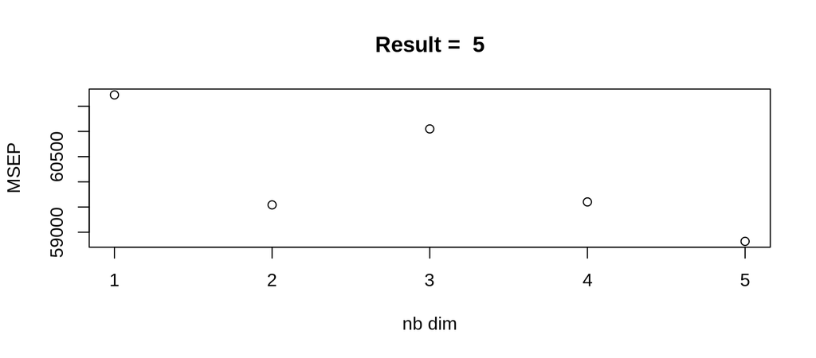

```r
nb2 <- estim_ncpPCA(airquality, method='Regularized', pNA=0.05,
          method.cv="Kfold", ncp.min=1, nbsim=150, verbose=FALSE)
plot(1:5, nb2$criterion, xlab="nb dim", ylab="MSEP")
title(paste("Result = ", nb2$ncp))
```

**3.** Kryterium kroswalidacji GCV może być postrzegane jako przybliżenie kryterium loo, które zapewnia prosty sposób oszacowania liczby wymiarów bez uciekania się do metod intensywnych obliczeniowo.

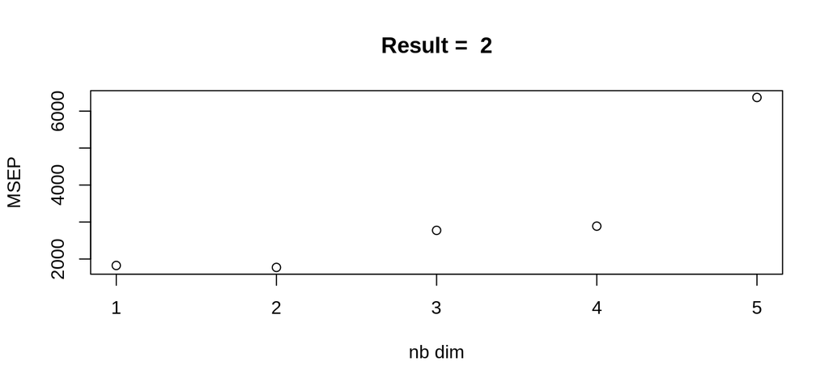

```r
nb3 <- estim_ncpPCA(airquality, method='Regularized', ncp.min=1,
                    method.cv="gcv", verbose=FALSE)
plot(1:5, nb3$criterion, xlab="nb dim", ylab="MSEP")
title(paste("Result = ", nb3$ncp))
```

## Imputacja

## Metoda ustandaryzowana

Standaryzowany iteracyjny algorytm PCA w pierwszym kroku polega na imputowaniu brakujących wartości wartościami początkowymi, takimi jak średnia zmiennej. Jeśli parametr seed ustawiony jest na określoną wartość, przeprowadzana jest losowa inicjalizacja: wartości początkowe są przypisane z rozkładu gaussowskiego ze średnią i odchyleniem standardowym obliczonym na podstawie zaobserwowanych wartości.  
Uwaga: można zdefiniować inną losową inicjalizację. W takiej sytuacji zachowane jest rozwiązanie dające najmniejszy błąd średniokwadratowy.

Drugim krokiem (standaryzowanego) iteracyjnego algorytmu PCA jest wykonanie PCA na skompletowanym zbiorze danych. Następnie przypisuje brakujące wartości za pomocą (uregulowanych) wzorów rekonstrukcyjnych rzędu ncp. Te etapy oszacowania parametrów za pomocą PCA i przypisania brakujących wartości z rozkładu rozmalnego są powtarzane iteracyjnie aż do uzyskania zbieżności.  
Zalecane jest korzystanie ze znormalizowanej wersji algorytmu, aby uniknąć problemów z nadmiernym dopasowaniem, które są bardzo częste, gdy w danych brakuje wielu wartości.

## Metoda ustandaryzowana

```r
res.comp <- imputePCA(airquality, ncp=nb3$ncp,
                      method="Regularized")

# Dane po imputacji
head(res.comp$completeObs)
```

```
##          Ozone  Solar.R Wind Temp Month Day
## [1,] 41.000000 190.0000  7.4   67     5   1
## [2,] 36.000000 118.0000  8.0   72     5   2
## [3,] 12.000000 149.0000 12.6   74     5   3
## [4,] 18.000000 313.0000 11.5   62     5   4
## [5,]  7.786466 183.7009 14.3   56     5   5
## [6,] 28.000000 202.1423 14.9   66     5   6
```

## Metoda EM

Metoda maksymalizacji wartości oczekiwanej to metoda estymacji parametrów modelu probabilistycznego ze zmiennymi ukrytymi polegająca na iteracyjnej maksymalizacji funkcji wiarygodności. Każda iteracja algorytmu EM składa się z dwóch kroków:  
1. **kroku E** , dla aktualnego układu parametrów rozkładu wyestymuj wartości, które zmaksymalizują wartość funkcji wiarygodności,  
2. **kroku M** , zmiana aktualnych parametrów rozkładu na takie, które prowadzą do modelu bardziej zgodnego z danymi.  
Kroki wykonywane są tak długo, aż pomiędzy kolejnymi przebiegami nie dochodzi do zauważalnej poprawy.

## Metoda EM

```r
res.comp <- imputePCA(airquality, ncp=nb3$ncp, method="EM")

# Dane po imputacji
head(res.comp$completeObs)
```

```
##          Ozone  Solar.R Wind Temp Month Day
## [1,] 41.000000 190.0000  7.4   67     5   1
## [2,] 36.000000 118.0000  8.0   72     5   2
## [3,] 12.000000 149.0000 12.6   74     5   3
## [4,] 18.000000 313.0000 11.5   62     5   4
## [5,] -5.172391 244.6936 14.3   56     5   5
## [6,] 28.000000 288.3683 14.9   66     5   6
```

## Wynik algorytmu PCA

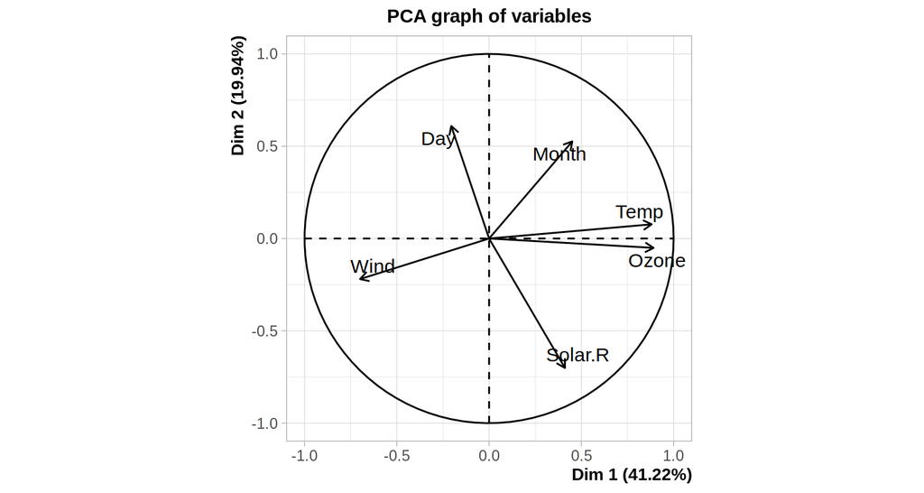

```r
res.pca <- PCA(res.comp$completeObs, graph=FALSE)
plot.PCA(res.pca, choix="var", graph.type='ggplot') +
  theme(plot.background=element_rect(fill=NA, color=NA))
```

## Interpretacja wykresu

Rozważane wymiary są kombinacjami liniowymi zmiennych.  
Punkty zaczepienia poszczególnych wektorów stanowią współczynniki w kombinacjach liniowych dla danej zmiennej odpowiednio w 1. i 2. nowo utworzonym wymiarze.  
Wykres pokazuje relacje między wszystkimi zmiennymi.  
Można go interpretować następująco:  
* Dodatnio skorelowane zmienne są grupowane razem.  
* Zmienne ujemnie skorelowane są umieszczone po przeciwnych stronach początku wykresu (przeciwne ćwiartki).  
* Długość wektora mierzy jakość zmiennych. Im dłuższy wektor, tym zmienna bardziej reprezentatywna.

Z sześciu wymiarów (wektory) mamy dwa (osie). Współrzędne każdego punktu w nowej przestrzeni można wyliczyć z kombinacji liniowej. Szukamy takiej kombinacji liniowej by zmaksymalizować wariancję w nowej przestrzeni. Procenty widoczne na osiach, to procenty wariancji danych, jakie są uwzględnione w danym wymiarze.

## Wizualizacja niepewności

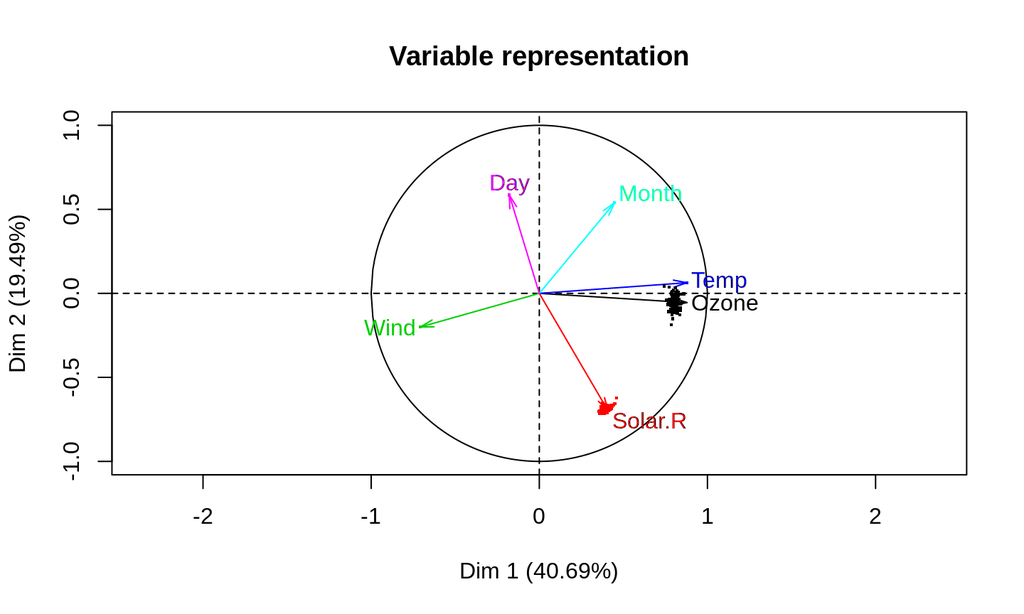

```r
res.mipca <- MIPCA(airquality, scale = TRUE, ncp = 2)
plot.MIPCA(res.mipca, 'var')
```

## Wizualizacja niepewności

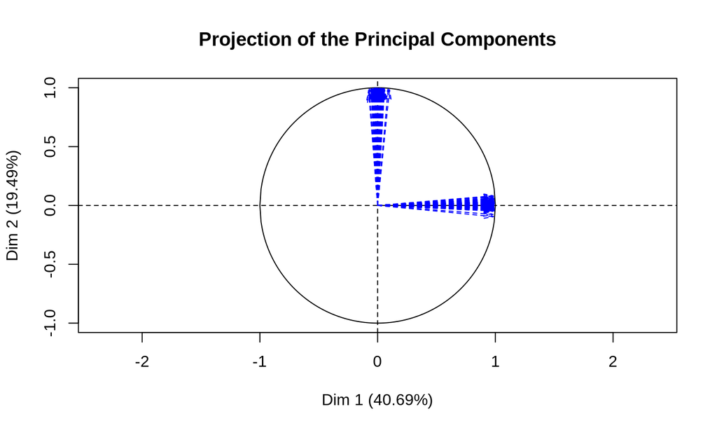

```r
plot.MIPCA(res.mipca, choice='dim')
```

## Zbiór danych vnf

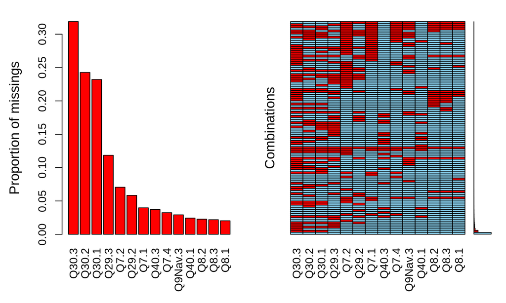

## Metoda MCA

Metoda MCA stanowi odpowiednik metody PCA dla zmiennych kategorycznych. Polega ona na zakodowaniu danych z brakami w postaci complete disjunctive table. Brakujące dane inicjalizowane są proporcjami kategorii, dla każdej kategorii, przy użyciu niebrakujacych wartości (proces ten bywa określany jako “missing fuzzy average method”). Następnie stosowana jest omówiona już metoda PCA. Wynikowa ramka, w miejsach pierwotnych braków, zawiera wartości z przedziału [0, 1], które mogą być interpretowane jako prawdopodobieństwa przynależności do danej kategorii.

## Przypadek zmiennych ciągłych (PCA)

|  | C1 | C2 |
| --- | --- | --- |
| Obs1 | 1 | 10 |
| Obs2 | 2 | 12 |
| Obs3 | 7 | 1 |
| Obs4 | 8 | 3 |
| Obs5 | ? 4.5 ? | 13 |

## Przypadek zmiennych kategorycznych (MCA)

Data table:

|  | Q1 | Q2 |
| --- | --- | --- |
| Obs1 | A | C |
| Obs2 | A | D |
| Obs3 | B | E |
| Obs4 | A | D |
| Obs5 | ? | D |

## Przypadek zmiennych kategorycznych (MCA)

Complete disjunctive table:

[output not shown]

## Imputacja

```r
nb4 <- estim_ncpMCA(vnf, method='Regularized',
                    verbose=FALSE, method.cv="Kfold")
plot(1:5, nb1$criterion, xlab="nb dim", ylab="MSEP")
title(paste("Result = ", nb4$ncp))
```

[output not shown]

## Imputacja

```r
res.comp <- imputeMCA(vnf, ncp=nb4$ncp,
                      method="Regularized")

# Dane po imputacji
res.comp$tab.disj[25:30, 1:6]
```

```
##       Q7.1.1    Q7.1.2    Q7.1.3    Q7.2.1  Q7.2.2    Q7.2.3
## 25 1.0000000 0.0000000 0.0000000 0.0000000 0.00000 1.0000000
## 26 0.5186529 0.3373625 0.1439846 0.2395126 0.34599 0.4144974
## 27 1.0000000 0.0000000 0.0000000 0.0000000 0.00000 1.0000000
## 28 0.0000000 1.0000000 0.0000000 0.0000000 0.00000 1.0000000
## 29 1.0000000 0.0000000 0.0000000 0.0000000 0.00000 1.0000000
## 30 1.0000000 0.0000000 0.0000000 0.0000000 0.00000 1.0000000
```

## Imputacja

```r
res.comp$completeObs[25:30, 1:2]
```

```
##    Q7.1 Q7.2
## 25    1    3
## 26    1    3
## 27    1    3
## 28    2    3
## 29    1    3
## 30    1    3
```

## Wynik algorytmu MCA

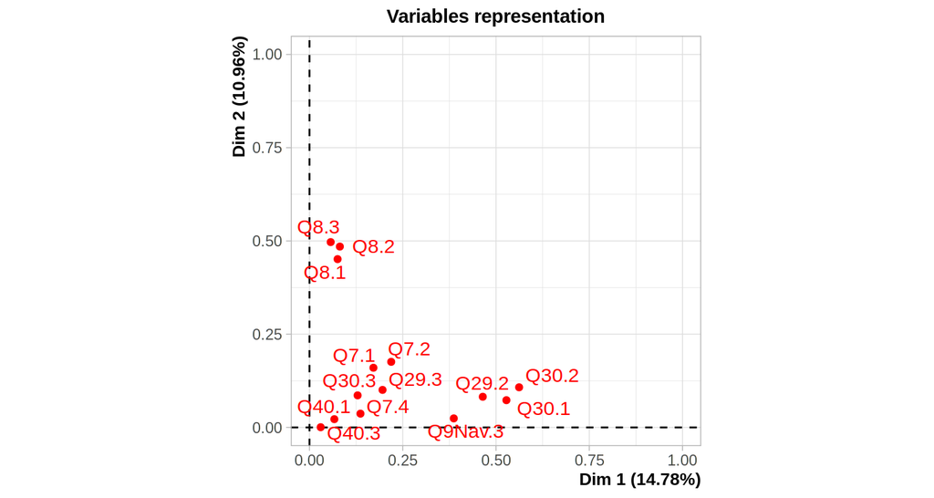

```r
res.pca <- MCA(res.comp$completeObs, graph=FALSE)
plot.MCA(res.pca, choix="var", graph.type='ggplot') +
  theme(plot.background=element_rect(fill=NA, color=NA))
```

## Wizualizacja niepewności

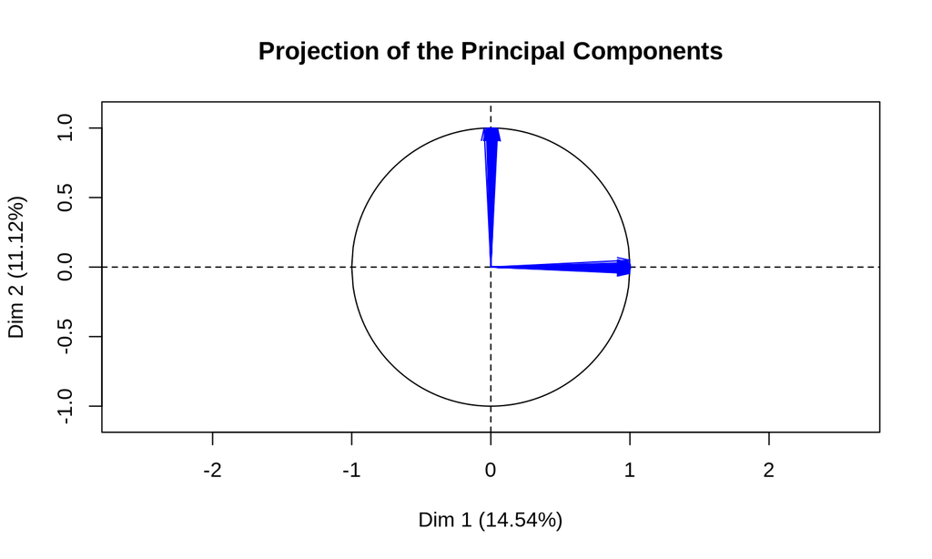

```r
res.mimca <- MIMCA(vnf, ncp=nb4$ncp)
plot.MIMCA(res.mimca, choice='dim')
```

## Zbiór danych vine

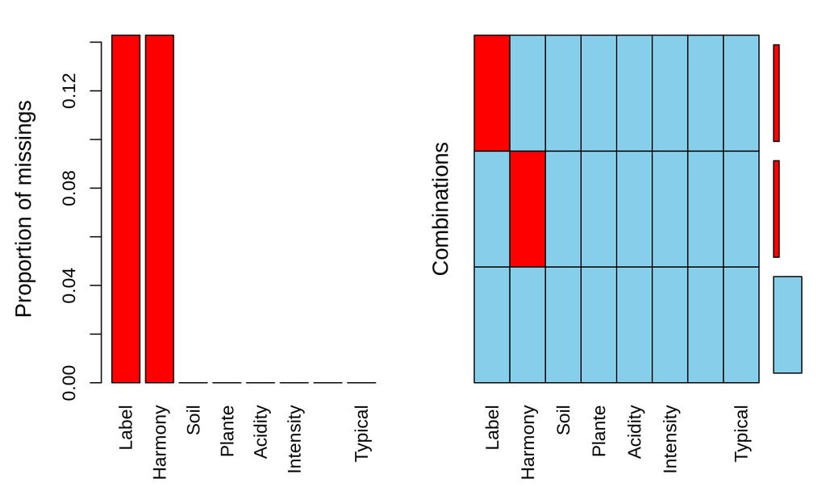

## Metoda FAMD

Z grubsza można powiedzieć, że FAMD (factor analysis of mixed data) działa jak PCA dla zmiennych ciągłych i MCA dla zmiennych kategorycznych.

Kiedy dane zawierają oba typy danych, ale obecnie aktywne zmienne są homogenicznych typów, PCA lub MCA może zostać użyte.

Kiedy aktywne dane są typów mieszanych, stosuje się dyskretyzację zmiennych ciągłych (np. wiek może zostać zamieniony na grupy wiekowe), a następnie może zostać użyte MCA.

## Estymacja ncp dla FAMD

```r
nb5 <- estim_ncpFAMD(wine, method='Regularized',
                    verbose=FALSE, method.cv="Kfold")
plot(1:5, nb1$criterion, xlab="nb dim", ylab="MSEP")
title(paste("Result = ", nb4$ncp))
```

[output not shown]

## Imputacja

```r
res.comp <- imputeFAMD(df, ncp=2,
                      method="Regularized")
# Dane po imputacji
res.comp$tab.disj[1:7,c(1:6,10)]
```

```
##     Saumur Bourgueuil     Chinon Reference Env1 Env2 Harmony
## 1 1.000000  0.0000000  0.0000000         0    1    0 3.14300
## 2 1.000000  0.0000000  0.0000000         0    1    0 2.96400
## 3 0.000000  1.0000000  0.0000000         0    1    0 3.14300
## 4 1.338701 -0.1471237 -0.1915772         0    0    1 2.03800
## 5 1.000000  0.0000000  0.0000000         1    0    0 3.64300
## 6 0.000000  1.0000000  0.0000000         1    0    0 3.50000
## 7 0.000000  1.0000000  0.0000000         1    0    0 3.53316
```

## Imputacja

```r
res.comp$completeObs[1:7, ]
```

```
##        Label      Soil Plante Acidity Harmony Intensity Overall.quality Typical
## 1     Saumur      Env1  2.000   2.107 3.14300     2.857           3.393   3.250
## 2     Saumur      Env1  2.000   2.107 2.96400     2.893           3.214   3.036
## 3 Bourgueuil      Env1  1.750   2.179 3.14300     3.074           3.536   3.179
## 4     Saumur      Env2  2.304   3.179 2.03800     2.462           2.464   2.250
## 5     Saumur Reference  1.762   2.571 3.64300     3.643           3.741   3.444
## 6 Bourgueuil Reference  1.750   2.393 3.50000     3.464           3.643   3.393
## 7 Bourgueuil Reference  1.826   2.607 3.53316     3.643           3.714   3.357
```

## Wynik algorytmu FAMD

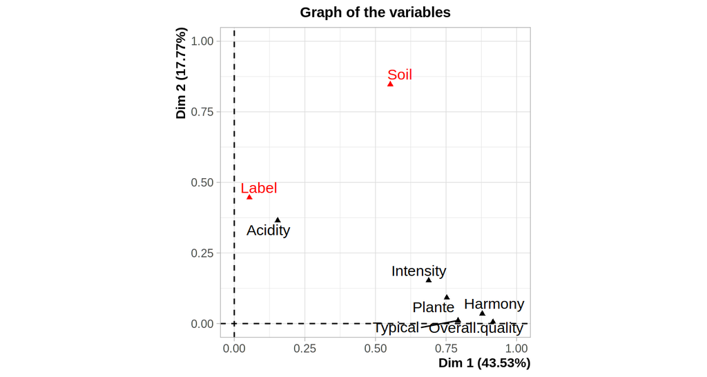

```r
res.famd <- FAMD(res.comp$completeObs, graph=FALSE)
plot.FAMD(res.famd, choix="var", graph.type='ggplot') +
  theme(plot.background=element_rect(fill=NA, color=NA))
```